# MP3

Phil Kaplan, Jaan Selod, Emma Laslo

2024-03-28

# Introduction

The purpose of Mini Project 3 is two-fold, (1) to quantify physical properties including Young’s modulus for a segment of intestine in both circumferential and longitudinal orientations during loading and unloading phases and (2) to compare flexural stiffness of a wooden stirrer in various orientations (flat/flipped), states (wet/dry), and with different rates of mass application (fast/slow). Both materials are anisotropic in that they have directionally dependent properties due to fiber arrangements. For example, wood grain is unidirectional and thus gives the material anisotropy, in that its “axial cellular elements” tend to be oriented similarly (Brémaud, Gril, and Thibaut 2011). Similarly, intestinal muscle is arranged both longitudinally and circumferentially, demonstrating the physiological connection between biology and function: pushing a bolus through the digestive tract. Young’s modulus is a property that assesses the relative ease at which the material is stretched. In essence, Young’s modulus is the ratio of stress to strain. According to Patel and Thavamani (2023), both the longitudinal and circumferential muscles of the intestine stretch and contract to enable the movement of food and waste during peristalsis. Notably, the intestine is more compliant along the circumferential axis in order to move varying volumes of food. This characteristic should be reflected in the relative difference between the Young’s modulus calculated for the longitudinal and circumferential conditions. Under expected conditions, the equation $d = (Fl^3)/3EI$ governs the calculated flexural stiffness for the wooden stirrer. The moment of inertia of the stirrer is dependent on its orientation. In the flipped condition, the moment of inertia should be significantly greater, resulting in greater flexural stiffness compared to the flat orientation. Water has plasticizing properties, suggesting that the observed flexural stiffness for the dry conditions should be greater than in the wet conditions (Mvondo et al. 2017). Finally, the rate at which the mass is applied to the stirrer is expected to have an effect on the measured flexural stiffness of the dowel. Under the slow condition, the stirrer is expected to undergo “creep”, which is a gradual deformation of the material yielding larger observed flexural stiffness values.

# Methods

Intestine Section:

A pig intestine was cut into 2 sections (5-8 cm x 1 cm) both for axial and circumferential orientations relative to the original intestine. The length, width, and thickness of the sections were obtained using calipers. Intestine sections were secured to a table using a binder clip. A make-shift weight holder was then secured to the end of the intestinal section using dental floss. Pairs of 3.2 gram washers were added until a total load of 8 washers was obtained. Length measurements of the intestine were obtained after each addition of the two washers. Then, washers were unloaded in pairs (as they were added), and length measurements were obtained each time the load was decreased.

Wood Section:

Length, width, and thickness measurements of a birch coffee stirrer were obtained. Utilizing a 3 point bending set-up, a load cell, and a program utilizing a cylinder to depress the wood, the mass required to depress the wood 1 mm was obtained. 5 total trials were conducted with varying conditions in each of the trials. In the first 4 trials, the wood was in a flat orientation. The state of the wood (wet/dry) and the speed at which the mass was applied (fast/slow) was varied for these trials. In the 5th trial, a dry piece of wood was flipped on its side and mass was applied slowly.

# Results

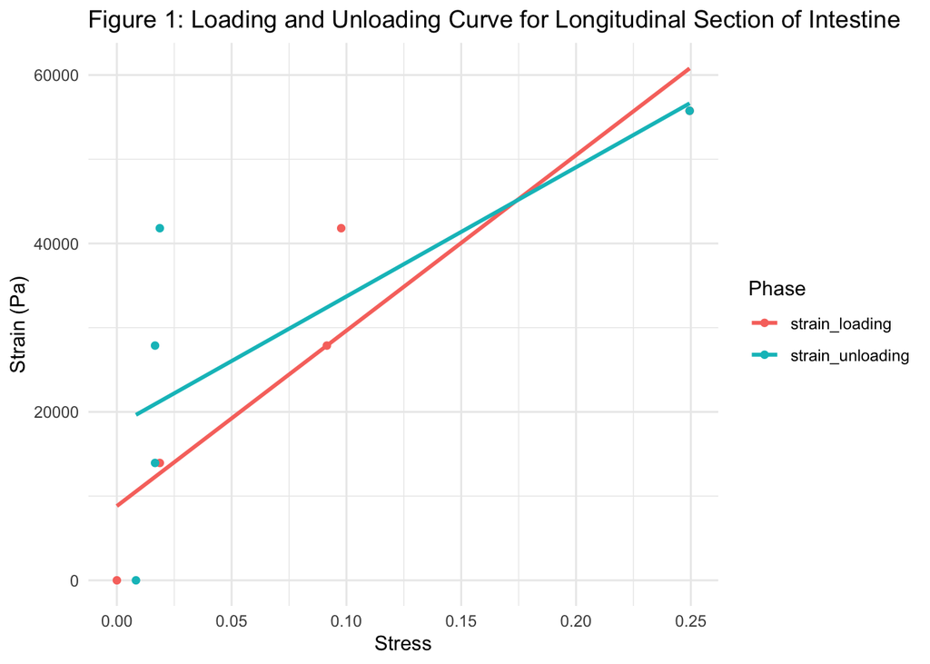

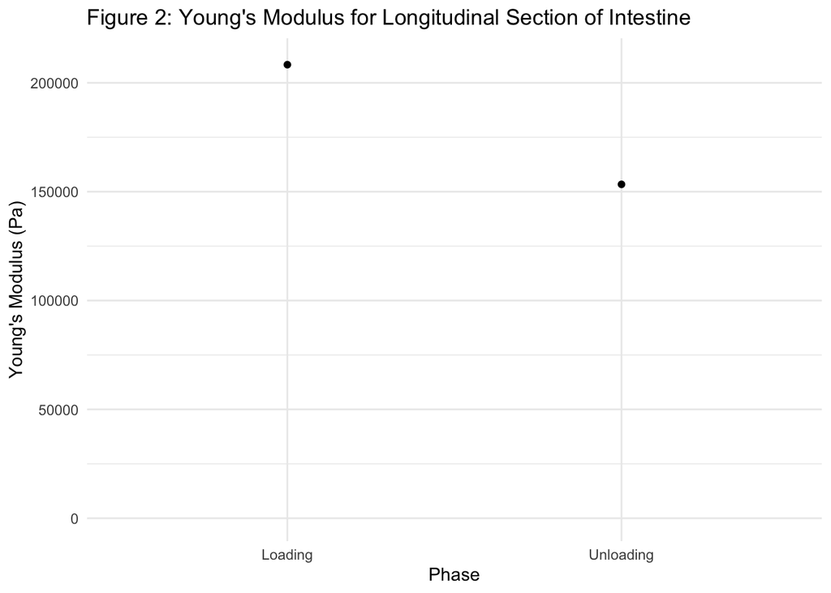

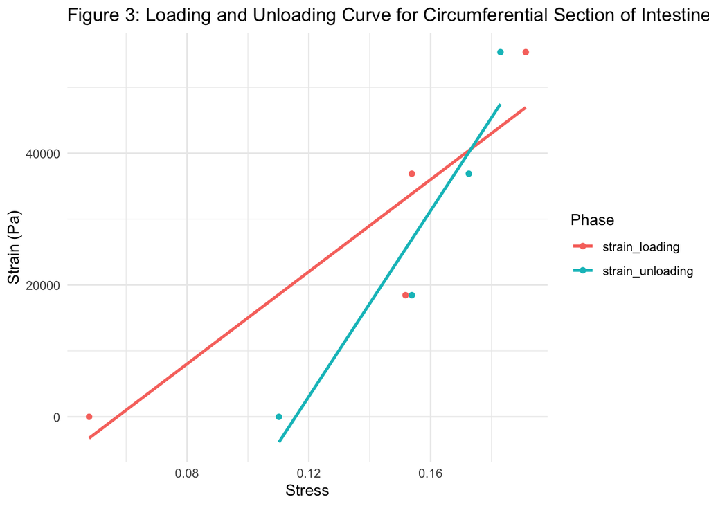

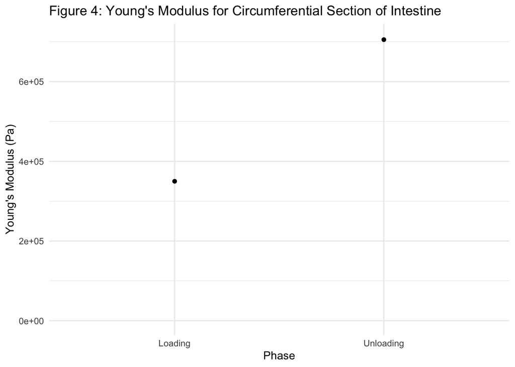

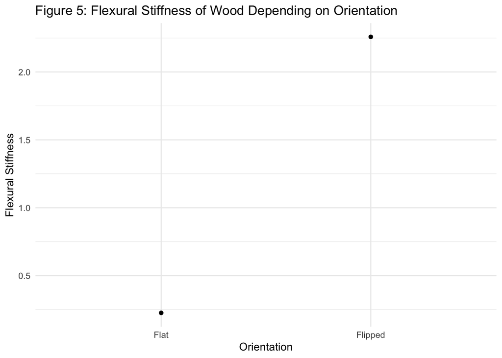

Table 1: Maximum Force (N) to Deflect Wood

| condition | fast | slow |
| --- | --- | --- |
| dry | 16.05485 | 14.52561 |
| wet | 10.87003 | 11.59069 |

Table 2: Wood Flexural Stiffness

| condition | fast | slow |
| --- | --- | --- |
| dry | 0.2496850 | 0.2259023 |
| wet | 0.1690507 | 0.1802584 |

# Discussion

# Author Contributions

- Phil:
  - Intro
  - Methods
  - Results (code)
  - Discussion
- Jaan:
  - Intro
  - Methods
  - Results (code for figures and tables)
  - Discussion
  - Bibliography

# Bibliography

Brémaud, I., J. Gril, and B. Thibaut. 2011. “Anisotropy of Wood Vibrational Properties: Dependence on Grain Angle and Review of Literature Data.” *Wood Science and Technology* 45. https://doi.org/10.1007/s00226-010-0393-8.

Mvondo, Rachel, Meukam Pierre, Jeong Jena, De Sousa Meneses Domingos, and Elambo Nkeng. 2017. “Influence of Water Content on the Mechanical and Chemical Properties of Tropical Wood Species.” *Results in Physics* 7: 2096–2103. https://www.sciencedirect.com/science/article/pii/S2211379717304862?via%3Dihub.

Patel, Kajal S., and Aravind Thavamani. 2023. *Physiology, Peristalsis*. StatPearls 2024 Publishing [Internet]. https://www.ncbi.nlm.nih.gov/books/NBK556137/.